# Classification

### J.A.

Under the probabilistic approach to classification, an object $x$ is classified as belonging to class $\omega_i$ with the highest posterior probability $p(\omega_i|x)$. For the majority of classifiers that follow this approach, the posterior probability is derived using the class-conditional density $p(x|\omega_i)$ in conjunction with Bayes' theorem. In the first two exercises however, we investigate one classifier that is an exception to this rule. Although its classification decision is still based on maximum posterior probability, the logistic classifier attempts to directly model the posterior distributions without first estimating the class-conditional densities.

## The Logistic Classifier

**Exercise 1**. In a binary classification problem with classes $\omega_1$ and $\omega_2$, for the logistic classifier the following is assumed:

$$ln \left( \dfrac{p(\textbf{x}|\omega_1 )}{p(\textbf{x}|\omega_2)} \right) = \textbf{w}_0 + \textbf{w}^T \textbf{x}$$

Show that using the above equation, one may derive the explicit form of the posterior probabilities, and write out these sigmoidal forms.

**Exercise 2**. Read in the file 'gaussian2D.txt' to access a labeled two-class Gaussian dataset. Build a logistic classifier using maximum likelihood estimation as shown below; find the predicted labels over the same dataset (method: **predict()**), then generate a confusion matrix (**confusion_matrix()** from **sklearn.metrics**) and compute the apparent error ie as measured over the training set.

```python
import numpy as np
import pandas as pd
import matplotlib.pyplot as plt
from sklearn.linear_model import LogisticRegression
from sklearn.metrics import confusion_matrix

path_to_file = './data/gaussian2D.txt'
data = pd.read_csv(path_to_file, sep=' ')

X = data.iloc[:,:-1]
y = data.iloc[:,-1]

model = LogisticRegression(solver='lbfgs').fit(X, y)
y_pred = model.predict(X)
confusion_matrix(y_true=y, y_pred=y_pred);
```

If your model runs correctly, you should obtain a linear classifier with zero classification error over this simple dataset. Additionally, provide a plot of one of the posterior distributions superimposed over a scatter plot of the data. Use the following code, but make sure you understand what it does.

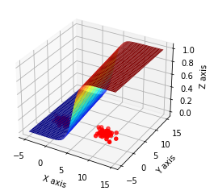

```python
w_0 = model.intercept_
w = model.coef_

x1 = np.linspace(-5,15,200)
x2 = np.linspace(-5,15,200)
x, y = np.meshgrid(x1, x2)

z = [[np.exp(w_0 + w.dot([i,j]))[0] / (1 + np.exp(w_0 + w.dot([i,j])))[0] for i in x1] for j in x2]
z = np.array(z)

ax = plt.axes(projection='3d')
ax.plot_surface(x,y,z,cmap='jet')
ax.scatter(X['f1'], X['f2'], np.zeros(X.shape[0])+0.1, c='red')
ax.set_xlabel('X axis')
ax.set_ylabel('Y axis')
ax.set_zlabel('Z axis')
plt.show()
```

## Basics of Classification

### Normal-based Discriminants

Following the probabilistic approach to classification, if the conditional density function is known, everything about the classification problem is known, and an optimal decision may be reached resulting in the lowest possible error in the theoretical case: Bayes' error. However, since in practice we need to estimate the class conditional densities, the final classification rate will depend on how accurate our estimate really is. Density estimation is not a trivial task. Some methods assume a Gaussian model for the class densities, whereas others may use the mixture of Gaussians method or make use of Parzen density estimation or k-nearest neighbor density estimation. In the following exercise, we will model the class density functions with a Gaussian model. Under the probabilistic approach to classification, the fundamental principles for solving any classification problem involve the following steps:

- Split your dataset into a training set and a test set.
- Estimate the class conditional probability density function for every class using the training set.
- For every object in the test set, compute the class conditional density.
- For every object in the test set, compute the posterior probability using Bayes' theorem.
- Assign every test object to the class with the highest posterior probability. The object will carry the corresponding class label.

**Exercise 3**. Read in 'trainfile.txt' and 'testfile.txt' to obtain labeled training and test sets respectively (note the datasets do not contain any headers). Let `X_train` and `X_test` represent the training set and test set respectively (without labels), and `y_train` and `y_test` represent the corresponding labels. Create a 2D scatter plot using the training set.

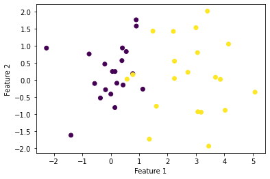

Next, divide the training set into two sets according to the class labels. Then estimate the probability density function for each class separately using a multivariate Gaussian. To do this, begin by computing the mean and covariance matrices: m1, m2, S1, S2.

Then compute the conditional probability density function for the test objects.

```python
m1 = X_train.loc[y_train==1].mean()
m2 = X_train.loc[y_train==2].mean()

S1 = np.cov(X_train.loc[y_train==1], rowvar=False)
S2 = np.cov(X_train.loc[y_train==2], rowvar=False)

n_obj, n_dim = X_test.shape

X_test_bar1 = X_test - np.tile(m1,(n_obj,1))
X_test_bar2 = X_test - np.tile(m2,(n_obj,1))

prob1 = 1/np.sqrt((2*np.pi)**n_dim*np.linalg.det(S1)) * \
        np.diag(np.exp(-0.5*(X_test_bar1).dot(np.linalg.inv(S1)).dot(X_test_bar1.T)))
prob2 = 1/np.sqrt((2*np.pi)**n_dim*np.linalg.det(S2)) * \
        np.diag(np.exp(-0.5*(X_test_bar2).dot(np.linalg.inv(S2)).dot(X_test_bar2.T)))
```

Explain why the expressions for the conditional probabilities include the use of **np.diag()** and how this speeds up execution by avoiding a *for* loop (though may not be suitable for large datasets memory-wise).

Set the class prior probabilities to 1/2, and use Bayes' theorem to evaulate the posterior probabilities for the test objects. Group the posterior probabilities into a 2D array as shown below, and check that the sum of each row is 1 as it should be.

```python
prior1, prior2 = 0.5, 0.5
px = prob1*prior1 + prob2*prior2

posterior1 = prob1*prior1/px
posterior2 = prob2*prior2/px
posterior = np.stack([posterior1,posterior2], axis=1)

posterior.sum(axis=1);
```

Find the class with the highest posterior probability for each object (hint: **argmax()** and add 1). By doing so, every object would receive a class label (either a 1 or 2). Congratulations! You have just constructed your own simple classifier. To evaluate the performance of your classifier, compare the correct class labels of the test objects `y_test` with the ones returned by your classifier. How many test objects were misclassified? What is then your classification error (ie as a percentage of total test objects)?

**Exercise 4**. The quadratic discriminant function may be written as:

$$f(\textbf{x}) = \textbf{x}^T \textbf{W} \textbf{x} + \textbf{w}^T \textbf{x} + w_0$$

Why is this classifier called the quadratic classifier?

**Exercise 5**. Using the same dataset as before, you will now construct a quadratic classifier using **QuadraticDiscriminantAnalysis()** from module **sklearn.discriminant_analysis**. Train the classifier as shown below. How many test objects are misclassified?

```python
from sklearn.discriminant_analysis import QuadraticDiscriminantAnalysis as qda

model = qda().fit(X_train, y_train)
y_pred = model.predict(X_test)

confusion_matrix(y_true=y_test, y_pred=y_pred);
```

Since our dataset is two-dimensional, we may visualize the decision boundary. Use the code below to do this. Describe what the code does in order to visualize the decision boundary? Is this method applicable to visualizing the boundary of any classifier in 2D?

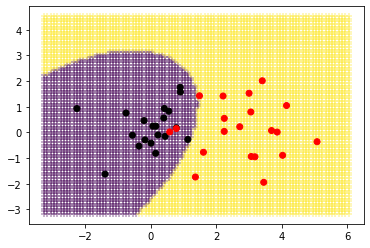

```python
#decision boundary
X = pd.concat([X_train, X_test]) #full dataset to derive axes limits

step = 0.1
x_min, x_max = X.iloc[:,0].min() - 1, X.iloc[:,0].max() + 1
y_min, y_max = X.iloc[:,1].min() - 1, X.iloc[:,1].max() + 1
xx, yy = np.meshgrid(np.arange(x_min,x_max,step), np.arange(y_min,y_max,step))

labels_pred = model.predict(np.c_[xx.ravel(), yy.ravel()])
Z = labels_pred.reshape(xx.shape)

plt.scatter(xx.ravel(), yy.ravel(), c=labels_pred, marker='+', alpha=0.4)
#plt.contour(xx, yy, Z, alpha=.6, cmap='gray') #optional contour
plt.scatter(X_train.iloc[:,0], X_train.iloc[:,1], c=y_train.replace({1:'black',2:'red'})) #plot this last
plt.show()
```

**Exercise 6**. A quadratic discriminant function with the assumption of equal class covariance matrices reduces to the linear normal-based discriminant function which may be written as:

$$f(\textbf{x})= \textbf{w}^T \textbf{x} + w_0$$

Using the same dataset as before, you will now construct the normal-based linear classifier using **LinearDiscriminantAnalysis()** (module: **sklearn.discriminant_analysis**). You only need to change the method in the previous code. Also visualize the decision boundary as before. What is the apparent error: how many training objects were misclassified? Verify the number of misclassified training objects by inspecting the scatter plot. What is the classification (test) error for this dataset?

**Exercise 7**. Read in the data file 'parallelclasses.txt' and create a 2D scatter plot. Train a linear normal-based classifier and visualize its decision boundary within the scatter plot. Repeat the same with the quadratic classifier. What is the apparent error for both classifiers? What seems to be the optimal decision boundary for this dataset?

**Exercise 8**. Read in the data file 'boomerang2D.txt' and inspect the scatter plot. Train a quadratic classifier and visualize the decision boundary. What is the apparent error for this dataset? Why is it so high? What minimum order do you think is required for a polynomial decision boundary to separate the data well?

## K-Nearest Neighbor Classifier

**Exercise 9**. Read in 'trainfile.txt' and 'testfile.txt' and create a scatter plot using the training set with different color for the two classes. Let `X_train` and `X_test` represent the training set and test set respectively (without labels), and `y_train` and `y_test` represent the corresponding labels. Train a k-nearest neighbor classifier on the dataset `X_train` with labels `y_train`, and test it on dataset `X_test`. Use **KNeighborsClassifier()** (module: **sklearn.neighbors**) with k = 3 as shown below. How many test objects have been misclassified? Visualize the decision boundary.

```python
from sklearn.neighbors import KNeighborsClassifier

model = KNeighborsClassifier(n_neighbors=3).fit(X_train, y_train)
y_pred = model.predict(X_test)

confusion_matrix(y_true=y_test, y_pred=y_pred)
error_apparent = (y_pred!=y_test).sum()
```

## The Curse of Dimensionality

The curse of dimensionality is a very important concept in machine learning. It sets a limit on the number of features to use for a given classification problem. As the dimension of the feature space increases, the classification error over an independent test set begins to increase after some point. In the next exercise, we shall explore this phenomenon more closely.

**Exercise 10**. We will plot the classification error as a function of dimensionality for randomly generated training and test sets. We vary the number of dimensions as follows: $d = [2, 3, 5, 10, 25, 100]$, and for each case, we generate 10 random draws from two $d$-dimensional Gaussian distributions to create training sets and test sets, then we average the classification results. The training set is intentionally kept small to emphasize the (curse of dimensionality) problem. Inspect the code below: by how much of a distance are the two Gaussian classes separated? Run the code to generate an errorbar plot. Based on this plot, how many features would you choose?

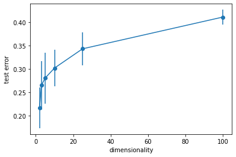

```python
dimensionality = [2,3,5,10,25,100]
error_test_mean, error_test_std = [],[]

for i in dimensionality:
    error_test = []
    for j in range(10):
        X1 = np.random.multivariate_normal(mean=np.zeros(i),cov=np.identity(i),size=10+1000)
        X2 = np.random.multivariate_normal(mean=np.append(2,np.zeros(i-1)),cov=np.identity(i),size=10+1000)

        X_train = np.concatenate([X1[:10,:],X2[:10,:]],axis=0)
        X_test = np.concatenate([X1[10:,:],X2[10:,:]],axis=0)
        y_train = np.repeat([1,2],10)
        y_test = np.repeat([1,2],1000)

        model = KNeighborsClassifier(n_neighbors=1).fit(X_train, y_train)
        y_pred = model.predict(X_test)
        error_test.append((y_pred!=y_test).mean())

    error_test_mean.append(np.mean(error_test))
    error_test_std.append(np.std(error_test))

plt.errorbar(dimensionality, error_test_mean, error_test_std)
plt.scatter(dimensionality, error_test_mean)
plt.xlabel('dimensionality')
plt.ylabel('test error')
plt.show()
```

## Who Am I?

Below is an attempt to implement a certain classifier from scratch for small-scale data. The function takes in a training set, training labels, a test set (for which it has to predict labels), and a hyperparameter 's'. The function returns two outputs. Study what the function seems to be doing and fill in the missing parts ('...') within the function so that it works properly (do not add any new lines inside the function). Additionally, one of the lines contains a minor bug: find and zap the bug. Identify the classifier this function is trying to implement and replace 'whoami' with a more suitable name. Explain how the class priors are being computed internally: does it make sense that they are computed so? (these are called empirical priors).

```python
'''
from sklearn.model_selection import train_test_split
from scipy.spatial import distance

def whoami(X_train, y_train, X_test, s):

    classes = y_train.unique()
    priors = y_train.value_counts()[classes].values/len(y_train)
    testDistMat = distance.cdist(X_test, X_train, 'euclidean')
    g = 1/(s*np.sqrt(2*np.pi))*np.exp(-0.5*(testDistMat/s)**2)
    p = np.zeros((X_test.shape[0], len(classes)))

    for i in range(len(classes)):
        tmp = g[:, y_train==...]
        p[:,i] = ...

    posteriors = priors*p/((priors*p).sum(axis=1, keepdims=True))
    labels = classes[p.argmax(axis=1)]

    return posteriors, labels
''';
```

Using "boomerang2D.txt" as dataset, how many test objects are misclassified for the below train/test split when `s=0.5`? Finally, train this classifier (with `s=0.5`) on the entire data in "boomerang2D.txt", and visualize the decision boundary within a scatter plot of the data. Try some other values for `s`: what happens when `s` is very low (eg 0.01) or very high (eg 3)?

```python
'''
#load dataset ...

X_train, X_test, y_train, y_test = train_test_split(X, y, train_size=0.8, stratify=y)

#call classifier and evaluate test error ...

#plot decision boundary (for when training over the entire dataset) ...

''';
```

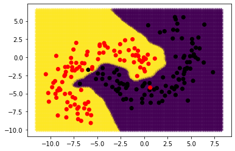